# TP3 Krigeage - Challenge 2025-2026

```r
#1. MUNOZ Enzo
#2. MUNIER Hugo
#3. GUILBAUD Maxime
```

# Notre prédiction

```r
set.seed(1234)
library(ggplot2)
library(GGally)
library(sp)
library(DiceKriging)
library(caret)
library(FactoMineR)
library(gstat)
```

## Collecte du jeu de données

```r
Observations <- read.csv("defi_observations.csv", header = TRUE)
X<- Observations[,-8]
Y<- Observations[,8]
n<- length(Y)
d<- length(X)

X_new = read.csv("DefiGroupeMUNOZ.csv", header = TRUE)
range_Y<- max(Y) - min(Y)
```

## Collecte du jeu de données

```r
cat("Observations : ", nrow(Observations), "lignes,", ncol(Observations), "colonnes\n")
```

```
## Observations :  700 lignes, 8 colonnes
```

```r
cat("Apredire     : ", nrow(X_new),     "lignes,", ncol(X_new),     "colonnes\n")
```

```
## Apredire     :  100 lignes, 8 colonnes
```

```r
cat("\nColonnes Observations :\n"); print(colnames(Observations))
```

```
##
## Colonnes Observations :
```

```
## [1] "X1" "X2" "X3" "X4" "X5" "X6" "X7" "Y"
```

```r
cat("\nColonnes Apredire :\n"); print(colnames(X_new))
```

```
##
## Colonnes Apredire :
```

```
## [1] "X1" "X2" "X3" "X4" "X5" "X6" "X7" "Y"
```

```r
cat("\nStructure Observations:\n"); str(Observations)
```

```
##
## Structure Observations:
```

```
## 'data.frame':    700 obs. of  8 variables:
##  $ X1: num  0.588 0.554 0.409 0.524 0.389 ...
##  $ X2: num  0.1969 0.4642 0.9765 0.0692 0.6651 ...
##  $ X3: num  0.829 0.135 0.366 0.972 0.318 ...
##  $ X4: num  0.724 0.341 0.657 0.376 0.28 ...
##  $ X5: num  0.638 0.229 0.131 0.296 0.277 ...
##  $ X6: num  0.585 0.907 0.454 0.92 0.689 ...
##  $ X7: num  0.5969 0.7538 0.0134 0.0404 0.8344 ...
##  $ Y : num  42.6 44.8 48.9 40.1 46.2 ...
```

```r
cat("\nStructure Apredire:\n"); str(X_new)
```

```
##
## Structure Apredire:
```

```
## 'data.frame':    100 obs. of  8 variables:
##  $ X1: num  0.982 0.907 0.641 0.496 0.77 ...
##  $ X2: num  0.553 0.535 0.711 0.61 0.153 ...
##  $ X3: num  0.317 0.513 0.514 0.733 0.451 ...
##  $ X4: num  0.0771 0.8594 0.8416 0.1388 0.5912 ...
##  $ X5: num  0.874 0.406 0.289 0.948 0.859 ...
##  $ X6: num  0.9805 0.5483 0.2038 0.0353 0.2814 ...
##  $ X7: num  0.218 0.886 0.523 0.395 0.16 ...
##  $ Y : num  54.1 50.2 50.1 51 43 ...
```

```r
cat("\nSummary Observations:\n"); print(summary(Observations))
```

```
##
## Summary Observations:
```

```
##        X1                  X2                  X3                 X4
##  Min.   :0.0008787   Min.   :0.0008053   Min.   :0.001368   Min.   :0.0000649
##  1st Qu.:0.2522255   1st Qu.:0.2449740   1st Qu.:0.241045   1st Qu.:0.2339814
##  Median :0.5002321   Median :0.4967091   Median :0.495200   Median :0.4936694
##  Mean   :0.4986947   Mean   :0.5012274   Mean   :0.492202   Mean   :0.4945884
##  3rd Qu.:0.7434984   3rd Qu.:0.7556081   3rd Qu.:0.741143   3rd Qu.:0.7425111
##  Max.   :0.9955380   Max.   :0.9980664   Max.   :0.998397   Max.   :0.9991097
##        X5                  X6                  X7                  Y
##  Min.   :0.0003065   Min.   :0.0009342   Min.   :0.0002899   Min.   :36.63
##  1st Qu.:0.2045868   1st Qu.:0.2507347   1st Qu.:0.2664103   1st Qu.:41.49
##  Median :0.4387354   Median :0.4783200   Median :0.5345779   Median :45.46
##  Mean   :0.4680260   Mean   :0.4982176   Mean   :0.5239151   Mean   :46.23
##  3rd Qu.:0.7279339   3rd Qu.:0.7630553   3rd Qu.:0.7847140   3rd Qu.:49.94
##  Max.   :0.9989900   Max.   :0.9986858   Max.   :0.9984179   Max.   :64.74
```

```r
cat("\nSummary Apredire:\n"); print(summary(X_new))
```

```
##
## Summary Apredire:
```

```
##        X1                 X2                 X3                 X4
##  Min.   :0.008839   Min.   :0.004145   Min.   :0.004376   Min.   :0.000738
##  1st Qu.:0.258988   1st Qu.:0.231744   1st Qu.:0.254110   1st Qu.:0.301220
##  Median :0.509326   Median :0.506857   Median :0.502059   Median :0.565016
##  Mean   :0.520068   Mean   :0.489072   Mean   :0.505673   Mean   :0.538117
##  3rd Qu.:0.811465   3rd Qu.:0.727000   3rd Qu.:0.752742   3rd Qu.:0.768508
##  Max.   :0.993425   Max.   :0.957013   Max.   :0.990836   Max.   :0.985769
##        X5                X6                 X7                 Y
##  Min.   :0.00147   Min.   :0.003334   Min.   :0.001465   Min.   :37.08
##  1st Qu.:0.18089   1st Qu.:0.260445   1st Qu.:0.285921   1st Qu.:41.44
##  Median :0.40417   Median :0.553941   Median :0.501544   Median :45.67
##  Mean   :0.44761   Mean   :0.530962   Mean   :0.509796   Mean   :46.22
##  3rd Qu.:0.68950   3rd Qu.:0.798056   3rd Qu.:0.784447   3rd Qu.:50.02
##  Max.   :0.99622   Max.   :0.985661   Max.   :0.993642   Max.   :61.56
```

```r
cat("\nNA par colonne (Observations):\n"); print(colSums(is.na(Observations)))
```

```
##
## NA par colonne (Observations):
```

```
## X1 X2 X3 X4 X5 X6 X7  Y
##  0  0  0  0  0  0  0  0
```

```r
cat("\nNA par colonne (Apredire):\n"); print(colSums(is.na(X_new)))
```

```
##
## NA par colonne (Apredire):
```

```
## X1 X2 X3 X4 X5 X6 X7  Y
##  0  0  0  0  0  0  0  0
```

Il n’y a que des variables entre 0 et 1 de moyenne proche de 0.5, ce qui est équivalent a tiré une loi uniforme dans [0,1].

## Visualisation du jeu de données

[output not shown]

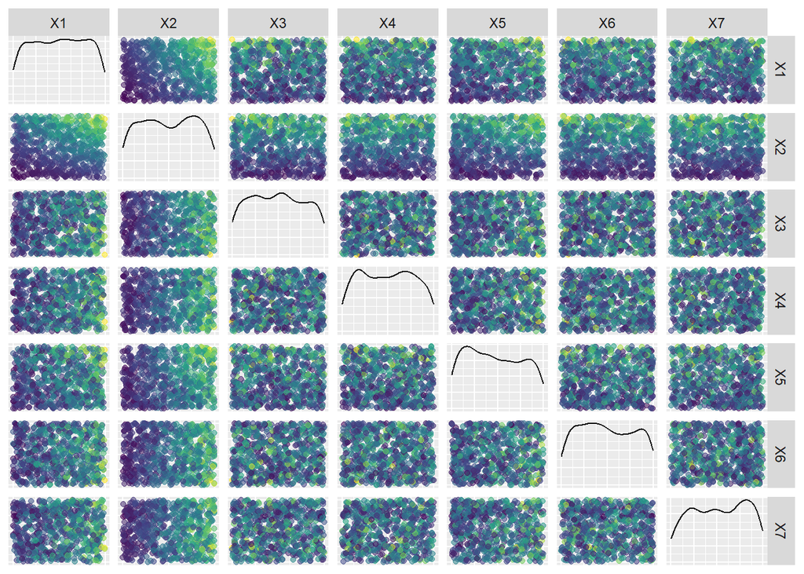

```r
Xcols <- paste0("X", 1:7)

ggpairs(
  Observations,
  columns = which(colnames(Observations) %in% Xcols),
  aes(color = Y, alpha = 0.6),
  upper = list(continuous = "points"),
  lower = list(continuous = "points"),
  diag  = list(continuous = "densityDiag")
) +
  scale_color_viridis_c() +
  theme(
    legend.position = "none",
    axis.text  = element_blank(),
    axis.ticks = element_blank(),
    axis.title = element_blank()
  )
```

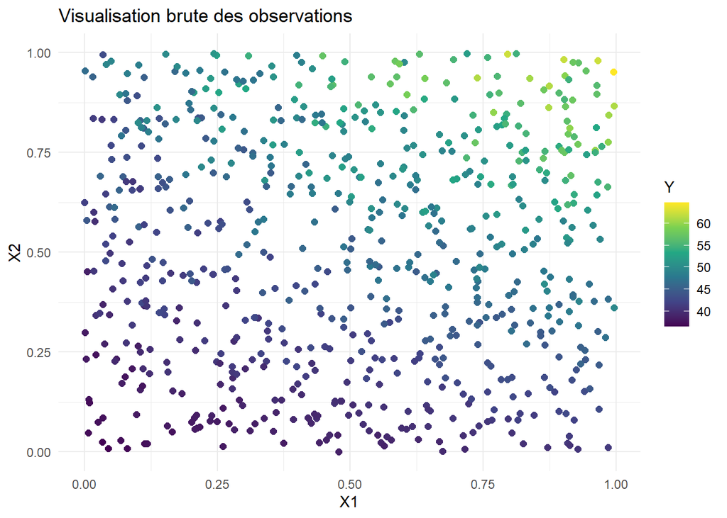

```r
ggplot(Observations, aes(x = X1, y = X2, color = Y)) +
  geom_point(size = 2) +
  scale_color_viridis_c() +
  labs(
    title = "Visualisation brute des observations",
    x = "X1",
    y = "X2",
    color = "Y"
  ) +
  theme_minimal()
```

En examinant cette matrice, on voit clairement que Y augmente lorsque les varaibles X1 et X2 augmentent. En revanche, aucune relation claire n’apparait entre les variables X3 à X7. Les valeurs de Y sont dispersées. On en déduit que X1 et X2 jouent un rôle important dans la structuration de Y.

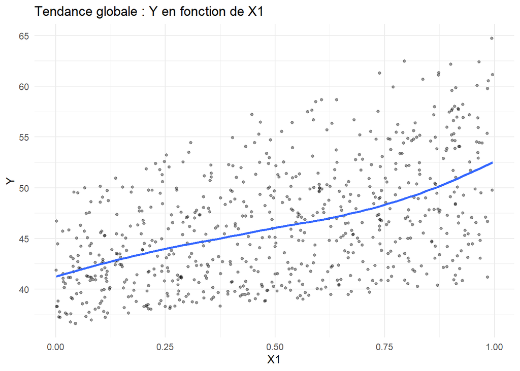

```r
# Y ~ X1
ggplot(Observations, aes(x = X1, y = Y)) +
  geom_point(alpha = 0.4, size = 1) +
  geom_smooth(se = FALSE) +
  labs(title = "Tendance globale : Y en fonction de X1", x = "X1", y = "Y") +
  theme_minimal()
```

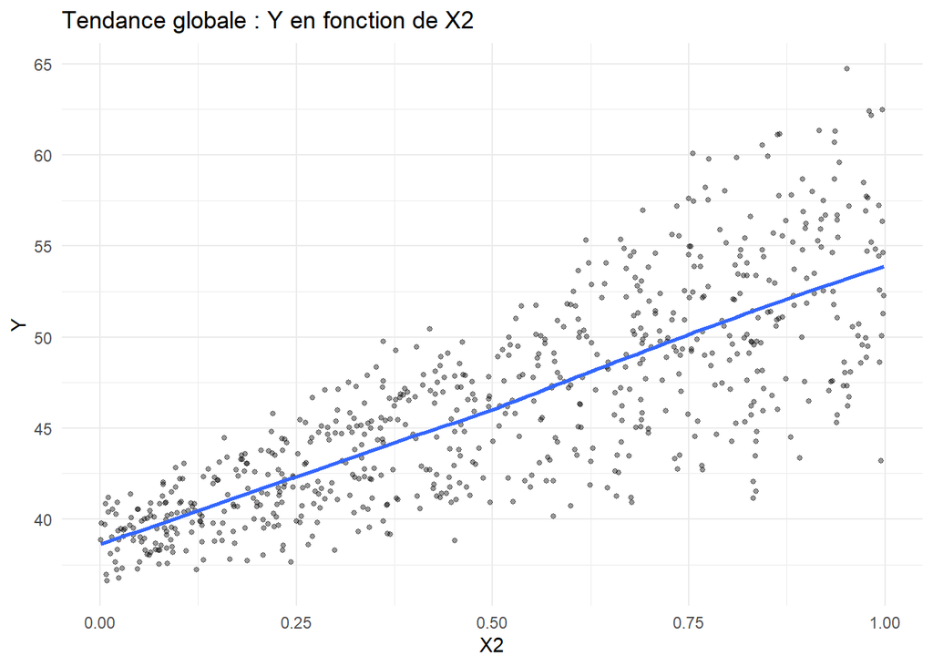

```r
# Y ~ X2
ggplot(Observations, aes(x = X2, y = Y)) +
  geom_point(alpha = 0.4, size = 1) +
  geom_smooth(se = FALSE) +
  labs(title = "Tendance globale : Y en fonction de X2", x = "X2", y = "Y") +
  theme_minimal()
```

Ces deux graphiques confirment que Y a une tendance globale croissante en fonction de X1 et de X2. Mais cette tendance est plus prononcée pour X2. De plus, on remarque sur les deux graphiques la présence d’une dispersion. Ces deux graphes nous conduisent à faire recours à un krigeage avec une tendance, soit le krigeage universel.

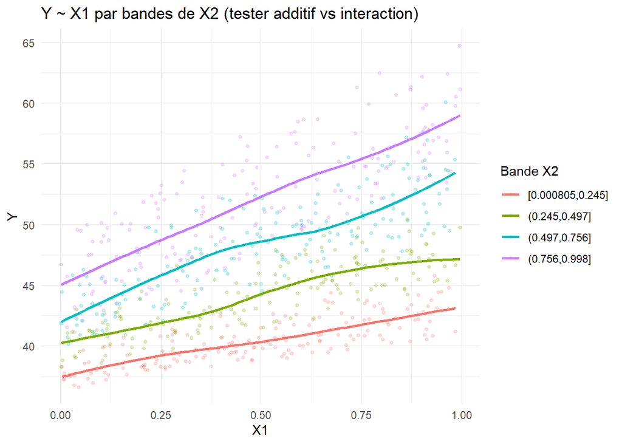

```r
# Création de bandes de X2 (4 groupes)
Observations$X2_bin <- cut(
  Observations$X2,
  breaks = quantile(Observations$X2, probs = seq(0, 1, 0.25)),
  include.lowest = TRUE
)

ggplot(Observations, aes(x = X1, y = Y, color = X2_bin)) +
  geom_point(alpha = 0.25, size = 1) +
  geom_smooth(se = FALSE) +
  labs(
    title = "Y ~ X1 par bandes de X2 (tester additif vs interaction)",
    x = "X1", y = "Y", color = "Bande X2"
  ) +
  theme_minimal()
```

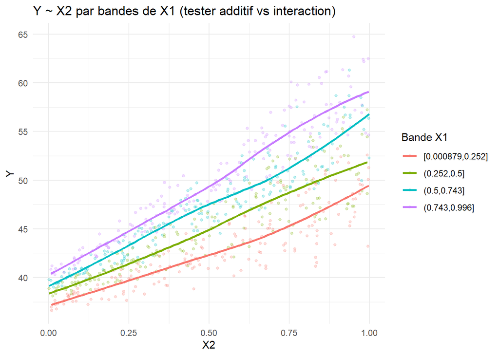

```r
Observations$X1_bin <- cut(
  Observations$X1,
  breaks = quantile(Observations$X1, probs = seq(0, 1, 0.25)),
  include.lowest = TRUE
)

ggplot(Observations, aes(x = X2, y = Y, color = X1_bin)) +
  geom_point(alpha = 0.25, size = 1) +
  geom_smooth(se = FALSE) +
  labs(
    title = "Y ~ X2 par bandes de X1 (tester additif vs interaction)",
    x = "X2", y = "Y", color = "Bande X1"
  ) +
  theme_minimal()
```

X1 par bandes de X2 montre homoscélasticité des résidus contrairement à X2 par bande de X1 où la variance des résidus semble augmenté en X2.

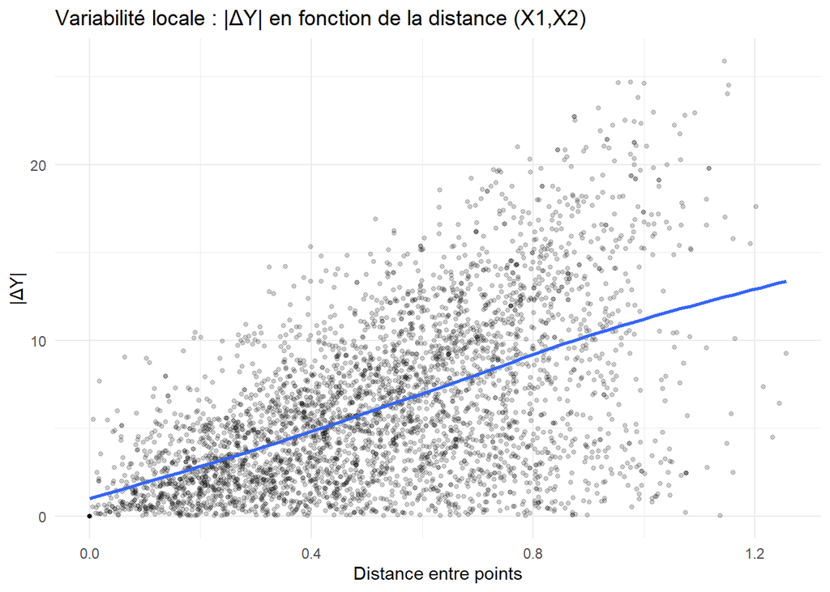

```r
n_s <- 250
idx <- sample(1:nrow(Observations), n_s)
S <- Observations[idx, c("X1", "X2", "Y")]

# Construire quelques paires aléatoires
m <- 4000
i <- sample(1:n_s, m, replace = TRUE)
j <- sample(1:n_s, m, replace = TRUE)

dx <- S$X1[i] - S$X1[j]
dy <- S$X2[i] - S$X2[j]
dist_ij <- sqrt(dx^2 + dy^2)
dY <- abs(S$Y[i] - S$Y[j])

df_pairs <- data.frame(dist = dist_ij, dY = dY)

ggplot(df_pairs, aes(x = dist, y = dY)) +
  geom_point(alpha = 0.2, size = 1) +
  geom_smooth(se = FALSE) +
  labs(
    title = "Variabilité locale : |ΔY| en fonction de la distance (X1,X2)",
    x = "Distance entre points",
    y = "|ΔY|"
  ) +
  theme_minimal()
```

On a voulu évaluer la dépendance spatiale de Y. Pour cela, on a tracé la différence absolue des valeurs de Y en fonction de la distance entre les points. On voit que les différences de Y augmentent avec la distance. Ainsi, les points proches présentent des valeurs plus similaires que les points éloignés. De plus, on voit que pour des distances très faible la différence absolue n’est pas forcément nulle ce qui suggère une variabilité locale.